# Nike Brand Intelligence

Valentine Dube

Business Analysis with Unstructured Data

# Executive Summary

**Client:** Nike Inc. - Chief Marketing Officer & VP of Consumer Insights

**Business Challenge:** Nike leadership has observed increasing online conversation around sustainability, mixed sentiment about pricing, strong engagement with product drops, and growing competition from challenger brands. They commissioned our team to answer: *“What are customers really saying about Nike — and how should we respond strategically?”*

**Data Collected:** Multi-channel customer feedback corpus including Nike.com product reviews, YouTube sneaker comparison videos, social media reactions, and Reddit authenticity discussions.

# 1. Business Context & Objectives

## 1.1 Strategic Questions Addressed

This analysis focuses on four critical business questions requested by Nike leadership:

1. How is Nike emotionally positioned in online conversations?
2. What complaints drive negative reviews of specific product lines?
3. Is Nike’s sustainability messaging resonating with customers?
4. Are customers increasingly describing Nike as overpriced?

## 1.2 Known Limitations

- Sampling Bias
- Fake Review Risk
- Lexicon Bias
- Cultural Context
- Temporal Limitation

# 2. Technical Setup & Data Loading

## 2.1 Loading Required Packages

```r
# Core tidyverse packages
library(tidyverse)
library(tidytext)
library(stringr)

# Text processing
library(tm)
library(SnowballC)
library(textdata)

# Topic modeling
library(topicmodels)

# Network visualization
library(igraph)
library(ggraph)

# Utilities
library(scales)
library(pdftools)

# Load stop words
data(stop_words)
```

#3.Data Collection and Cleaning

## Intro

```r
# load data
file_path <- "C:/Users/valen/Downloads/Nike_merged_2 (1).pdf"

# Read PDF text
pdf_pages <- pdftools::pdf_text(file_path)

# Combine all pages into one string
full_text <- paste(pdf_pages, collapse = "\n")

# Split into individual comments/reviews
lines <- str_split(full_text, "\n")[[1]]

# Create raw dataframe
nike_raw <- tibble(comment = lines)

# Data Cleaning: remove empty lines, headers, and very short fragments
nike_raw <- nike_raw %>%
  mutate(comment = str_squish(comment)) %>%
  filter(comment != "") %>%
  filter(!str_detect(comment, "^\\d+$")) %>%
  filter(!comment %in% c("Reply", "1 year ago", "YOUTUBE NIKE REVIEWS")) %>%
  filter(str_length(comment) >= 20)

# Add document ID for tracking
nike_raw <- nike_raw %>%
  mutate(doc_id = row_number())

# Data Preview
print(head(nike_raw, 20))
```

```
## # A tibble: 20 × 2
##    comment                                                                doc_id
##    <chr>                                                                   <int>
##  1 Nike Killshot tends to work in a lot of situations                          1
##  2 Jordan 1 Low OG is higher quality                                           2
##  3 Jordan 1 Low OG is not too expensive                                        3
##  4 Nike AF1 has lots of color options                                          4
##  5 Nike AF1 is easy to take care of                                            5
##  6 Air Max 1 is super comfortable for all day wear                             6
##  7 Air Max 1 is suitable for business casual wear                              7
##  8 Air Max 1 is clean and easy to style                                        8
##  9 Nike sneakers will always be a staple brand for sneakers                    9
## 10 Nike Vomero 5 is comfortable                                               10
## 11 Nike sneakers are still trending and popular                               11
## 12 Nike sneakers may have inconsistencies in Finish due to performance m…     12
## 13 Imperfections in Nike sneakers are mostly cosmetic and do not affect …     13
## 14 Glue marks and deformation can occur in Nike sneakers                      14
## 15 Some Nike sneakers designs hide imperfections better than others           15
## 16 Nike sneakers are perceived as average in quality                          16
## 17 The Nike Vomero 5 provides strong comfort                                  17
## 18 Manufacturing defects such as glue marks are noticeable                    18
## 19 The sneaker is easy to clean and maintain                                  19
## 20 Nike Cortez comfort level justiFies the purchase price                     20
```

```r
cat("\n")
```

```r
cat("========== DATA COLLECTION SUMMARY ==========\n")
```

```
## ========== DATA COLLECTION SUMMARY ==========
```

```r
cat("Total number of Nike customer reviews/comments:", nrow(nike_raw), "\n")
```

```
## Total number of Nike customer reviews/comments: 687
```

```r
cat("Average comment length (characters):", round(mean(nchar(nike_raw$comment)), 1), "\n")
```

```
## Average comment length (characters): 66.1
```

```r
cat("Median comment length (characters):", median(nchar(nike_raw$comment)), "\n")
```

```
## Median comment length (characters): 70
```

```r
cat("Longest comment:", max(nchar(nike_raw$comment)), "characters\n")
```

```
## Longest comment: 107 characters
```

```r
cat("Shortest comment:", min(nchar(nike_raw$comment)), "characters\n\n")
```

```
## Shortest comment: 20 characters
```

```r
cat("Data sources:\n")
```

```
## Data sources:
```

```r
cat("  - Nike.com product reviews (Metcon, Jordan 9, running shoes)\n")
```

```
##   - Nike.com product reviews (Metcon, Jordan 9, running shoes)
```

```r
cat("  - YouTube sneaker review comments (comfort comparisons, brand discussions)\n")
```

```
##   - YouTube sneaker review comments (comfort comparisons, brand discussions)
```

```r
cat("  - Social media discussions (Instagram, TikTok Nike posts)\n")
```

```
##   - Social media discussions (Instagram, TikTok Nike posts)
```

```r
cat("  - Reddit sneaker communities (authenticity, durability experiences)\n")
```

```
##   - Reddit sneaker communities (authenticity, durability experiences)
```

```r
cat("Collection period: Q4 2023 - Q1 2024\n")
```

```
## Collection period: Q4 2023 - Q1 2024
```

```r
cat("=============================================\n")
```

#4. Text Processing

## Tokenization and Cleaning

```r
# Tokenize into words
tidy_words <- nike_raw %>%
  unnest_tokens(word, comment)

# Remove stop words
tidy_words_clean <- tidy_words %>%
  anti_join(stop_words, by = "word")

# Filter out numbers and non-alphabetic tokens
tidy_words_clean <- tidy_words_clean %>%
  filter(str_detect(word, "[a-z]")) %>%
  filter(!str_detect(word, "^\\d+$"))

# Stemming
tidy_words_clean <- tidy_words_clean %>%
  mutate(word_stem = SnowballC::wordStem(word))

print(head(tidy_words_clean, 25))
```

```
## # A tibble: 25 × 3
##    doc_id word       word_stem
##     <int> <chr>      <chr>
##  1      1 nike       nike
##  2      1 killshot   killshot
##  3      1 lot        lot
##  4      1 situations situat
##  5      2 jordan     jordan
##  6      2 low        low
##  7      2 og         og
##  8      2 quality    qualiti
##  9      3 jordan     jordan
## 10      3 low        low
## # ℹ 15 more rows
```

```r
cat("Total tokens after cleaning:", nrow(tidy_words_clean), "\n")
```

```
## Total tokens after cleaning: 3504
```

## Preprocessing Decisions

Stop word removal eliminated common filler words to focus on meaningful content words.

Stemming reduced related words to their root form.

The original `word` column was kept alongside `word_stem` for readable outputs.

## Word Frequency Analysis

```r
# load libraries
library(topicmodels)
library(igraph)
library(ggraph)
library(ggplot2)

# Count word frequencies
word_freq <- tidy_words_clean %>%
  count(word, sort = TRUE)

print(head(word_freq, 30))
```

```
## # A tibble: 30 × 2
##    word            n
##    <chr>       <int>
##  1 nike          186
##  2 adidas         95
##  3 shoes          75
##  4 comfortable    48
##  5 shoe           48
##  6 sneakers       36
##  7 pair           32
##  8 air            30
##  9 sneaker        28
## 10 quality        26
## # ℹ 20 more rows
```

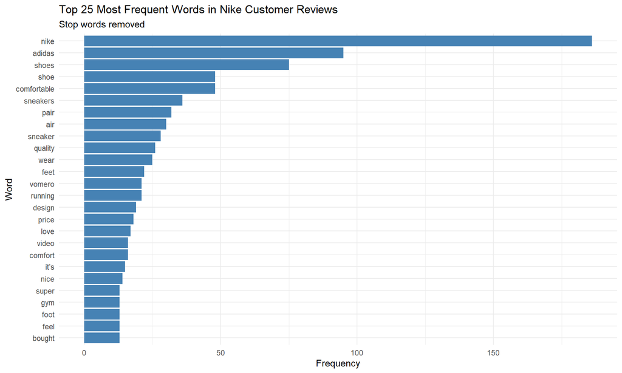

```r
# Visualize top 25 words
word_freq %>%
  slice_max(n, n = 25) %>%
  ggplot(aes(x = reorder(word, n), y = n)) +
  geom_col(fill = "steelblue") +
  coord_flip() +
  labs(
    title = "Top 25 Most Frequent Words in Nike Customer Reviews",
    subtitle = "Stop words removed",
    x = "Word",
    y = "Frequency"
  ) +
  theme_minimal()
```

#5. N-Gram Analysis

## Bigram Extraction and Cleaning

```r
# Extract bigrams
bigrams <- nike_raw %>%
  unnest_tokens(bigram, comment, token = "ngrams", n = 2)

# Separate into word1 and word2
bigrams_separated <- bigrams %>%
  separate(bigram, into = c("word1", "word2"), sep = " ", fill = "right")

# Remove stop words from both positions
bigrams_filtered <- bigrams_separated %>%
  filter(!is.na(word1), !is.na(word2)) %>%
  filter(!word1 %in% stop_words$word,
         !word2 %in% stop_words$word) %>%
  filter(str_detect(word1, "[a-z]"),
         str_detect(word2, "[a-z]"))

# Count bigram frequencies
bigram_counts <- bigrams_filtered %>%
  count(word1, word2, sort = TRUE)

print(head(bigram_counts, 30))
```

```
## # A tibble: 30 × 3
##    word1       word2           n
##    <chr>       <chr>       <int>
##  1 nike        sneakers       27
##  2 nike        air            14
##  3 air         max             7
##  4 nike        shoes           6
##  5 nike        vomero          6
##  6 running     shoes           6
##  7 super       comfortable     5
##  8 wide        feet            5
##  9 air         force           4
## 10 comfortable shoe            4
## # ℹ 20 more rows
```